# Age and Covid-19 outcomes

Holden Huntzinger

Acknowledgements: My data came from https://www.kaggle.com/tanmoyx/covid19-patient-precondition-dataset?select=covid.csv. Thanks to Kaggle user Tanmoy Mukherjee for translating, cleaning, and uploading this data, which they originally found released publicly by the Mexican government at https://www.gob.mx/salud/documentos/datos-abiertos-152127.

My goal here is to analyze the relationship between age and mortality of Covid-19 patients in this dataset.

# Exploration

First, I’ll reformat the entry_date values for easier analysis, add a binary column called death, and make sure empty values show up appropriately.

I see 566,602 observations of 24 variables focusing on admissions, outcomes, and pre-existing conditions of patients diagnosed with Covid-19 in Mexican hospitals.

```r
covid_data = read.csv("covid.csv")

# take 10,000 results randomly from the larger sample to speed up the rest of the code
covid_data = sample_n(covid_data, 10000)

covid_data = covid_data %>%
  mutate(entry_date = as.Date(entry_date, "%d-%m-%y")) %>%
  mutate(death = ifelse(covid_data$date_died == "9999-99-99", FALSE, TRUE))

covid_data[covid_data == 98] <- NA
covid_data$date_died = na_if(covid_data$date_died, "9999-99-99")

glimpse(covid_data)
```

```
## Rows: 10,000
## Columns: 24
## $ id                  <chr> "116cc0", "15c566", "00224b", "15d116", "1850cd", …
## $ sex                 <int> 2, 2, 1, 2, 1, 1, 2, 1, 1, 2, 2, 1, 1, 2, 2, 1, 2,…
## $ patient_type        <int> 1, 1, 1, 1, 1, 2, 2, 1, 1, 1, 1, 1, 1, 1, 1, 1, 1,…
## $ entry_date          <date> 2020-04-21, 2020-05-15, 2020-06-29, 2020-05-28, 2…
## $ date_symptoms       <chr> "18-04-2020", "07-05-2020", "22-06-2020", "23-05-2…
## $ date_died           <chr> NA, NA, NA, NA, NA, NA, NA, NA, NA, NA, NA, NA, NA…
## $ intubed             <int> 97, 97, 97, 97, 97, 2, 2, 97, 97, 97, 97, 97, 97, …
## $ pneumonia           <int> 1, 2, 2, 2, 2, 1, 2, 2, 2, 2, 2, 2, 2, 2, 2, 2, 2,…
## $ age                 <int> 49, 33, 40, 34, 45, 80, 66, 53, 36, 31, 44, 49, 52…
## $ pregnancy           <int> 97, 97, 2, 97, 2, 2, 97, 2, 2, 97, 97, 2, 2, 97, 9…
## $ diabetes            <int> 2, 2, 2, 2, 2, 2, 1, 1, 2, 2, 2, 2, 1, 2, 1, 2, 2,…
## $ copd                <int> 2, 2, 2, 2, 2, 2, 2, 2, 2, 2, 2, 2, 2, 2, 2, 2, 2,…
## $ asthma              <int> 2, 2, 2, 2, 2, 2, 2, 2, 2, 2, 2, 2, 2, 2, 2, 2, 2,…
## $ inmsupr             <int> 2, 2, 2, 2, 2, 2, 2, 2, 2, 2, 2, 2, 2, 2, 2, 2, 2,…
## $ hypertension        <int> 2, 2, 2, 2, 2, 2, 1, 2, 2, 2, 1, 2, 2, 2, 2, 2, 2,…
## $ other_disease       <int> 2, 2, 2, 2, 2, 2, 2, 2, 2, 2, 2, 2, 2, 2, 2, 2, 2,…
## $ cardiovascular      <int> 2, 2, 2, 2, 2, 2, 2, 2, 2, 2, 2, 2, 2, 2, 2, 2, 2,…
## $ obesity             <int> 1, 2, 2, 2, 2, 2, 2, 2, 2, 2, 2, 2, 2, 2, 2, 2, 2,…
## $ renal_chronic       <int> 2, 2, 2, 2, 2, 2, 2, 2, 2, 2, 2, 2, 2, 2, 2, 2, 2,…
## $ tobacco             <int> 1, 2, 2, 2, 2, 2, 2, 2, 2, 2, 2, 2, 2, 2, 2, 2, 2,…
## $ contact_other_covid <int> 99, 1, 99, 99, 2, 99, 2, 99, 99, 1, 99, 99, 99, 2,…
## $ covid_res           <int> 1, 1, 3, 1, 2, 2, 1, 2, 1, 2, 2, 2, 3, 2, 1, 2, 2,…
## $ icu                 <int> 97, 97, 97, 97, 97, 2, 2, 97, 97, 97, 97, 97, 97, …
## $ death               <lgl> FALSE, FALSE, FALSE, FALSE, FALSE, FALSE, FALSE, F…
```

Let’s look at some descriptive statistics to get a better sense of the data we’re working with. We can get a basic sense of when these records are from and how commonly patients saw negative outcomes after hospitalization.

```r
covid_data %>%
  summarize(first_date = min(entry_date),
            last_date = max(entry_date),
            last_death = max(date_died, na.rm=T))
```

```
##   first_date  last_date last_death
## 1 2020-01-06 2020-06-29 31-05-2020
```

It looks like this data covers the first 6 months of 2020. About 6.4% of these patients died, but it seems significant that the last death date recorded here is at the end of May. Is it possible that no one died in the month of June? It seems more likely to me that deaths occurring after a certain point are not recorded here. It’s OK that we’re using imperfect data, but we should always watch out for and note its limitations.

Next, let’s look at changes in case rates over time to get a sense of the temporality of this data.

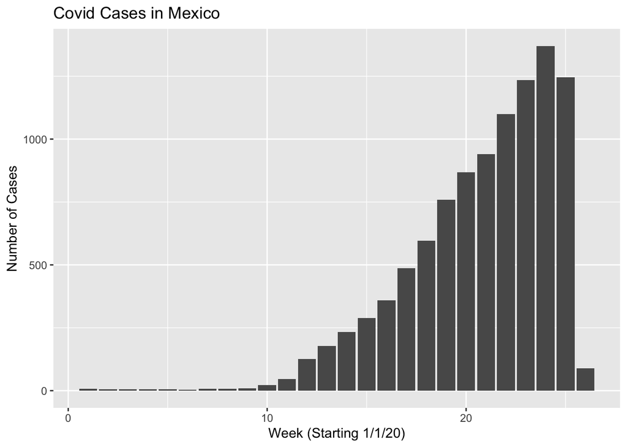

```r
cases_per_week = covid_data %>%
  mutate(week = cut.Date(entry_date, breaks = "1 week", labels = FALSE)) %>%
  group_by(week) %>%
  tally()

ggplot(cases_per_week, aes(x=week, y=n)) +
  geom_col() +
  labs(x='Week (Starting 1/1/20)', y='Number of Cases', title='Covid Cases in Mexico')
```

As we might expect remembering the trajectory of the pandemic in many other countries, there are very few records before week 10 (which is the week of March 11). Then, case numbers skyrocketed, aided by sudden awareness and testing capabilities. SARS-CoV-2 was spreading rapidly, but it’s worth remembering that this spread is only measured when cases of Covid-19 are diagnosed.

# The Hypothesis

I’ve heard and read consistently that age is one important factor in determining how hard Covid-19 will hit someone. Young people still see awful outcomes, and plenty of older people just cough for a few days and are fine, but mostly age seems to matter.

I want to prove it for myself, though. Based on what I hear in the news, I’ll start with the hypothesis that younger people will be less likely to die from Covid-19 after being hospitalized, and that this dataset will demonstrate this fact.

We’ll set a confidence interval at 0.95, meaning if we find that 95% of samples would tell us the same result, we feel comfortable saying we have confirmed our hypothesis.

# Description and Visualization

Let’s start by checking out the average ages of people who died after being hospitalized and those who didn’t.

```r
covid_data %>%
  group_by(death) %>%
  summarize(mean_age_survived = mean(age, na.rm=T))
```

```
## # A tibble: 2 × 2
##   death mean_age_survived
##   <lgl>             <dbl>
## 1 FALSE              41.4
## 2 TRUE               61.0
```

Box plots can be a helpful way to visualize data like this and to check for outliers.

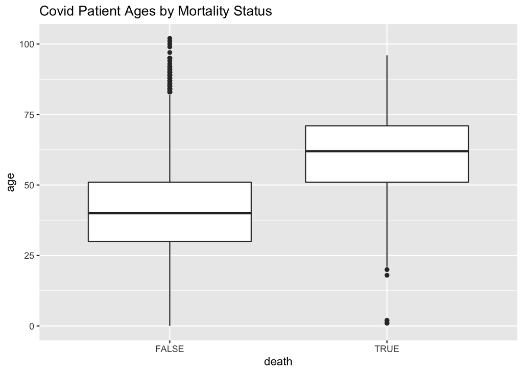

```r
ggplot(covid_data, aes(x=death, y=age)) +
  geom_boxplot() +
  labs(title = "Covid Patient Ages by Mortality Status")
```

We can see the different medians (which look quite similar to the means we calculated above) here clearly, but there are SO many outliers! Let’s quickly learn more about some of those.

```r
covid_data %>%
  summarize(min_age = min(age, na.rm=T),
            max_age = max(age, na.rm=T))
```

```
##   min_age max_age
## 1       0     102
```

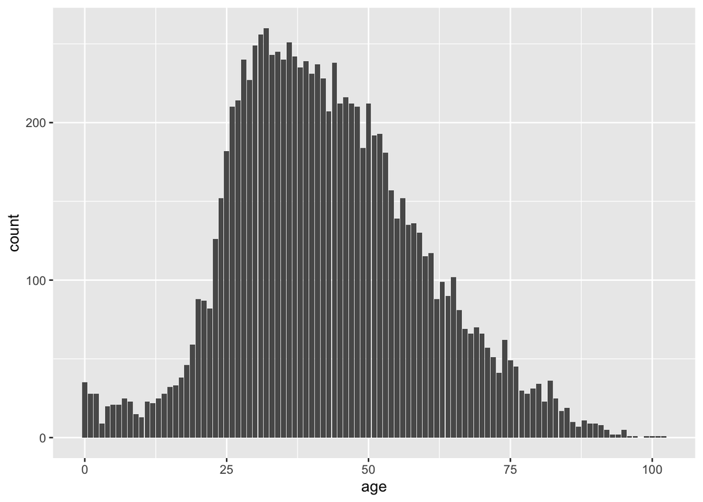

```r
covid_age = covid_data %>%
  group_by(age) %>%
  ggplot(aes(x=age)) +
  geom_bar()

covid_age
```

It’s worthwhile to note that this isn’t a random sample of people - it’s a random sample of people who were hospitalized. One result of this selection process is that people of all ages aren’t equally represented.

Now that we understand these caveats and limitations, we can move ahead with this analysis.

# Proving the Connection

```r
covid_small = covid_data %>%
  select(age) %>%
  mutate(survived = ifelse(covid_data$death == TRUE, "yes", "no"))

glimpse(covid_small)
```

```
## Rows: 10,000
## Columns: 2
## $ age      <int> 49, 33, 40, 34, 45, 80, 66, 53, 36, 31, 44, 49, 52, 75, 67, 3…
## $ survived <chr> "no", "no", "no", "no", "no", "no", "no", "no", "no", "no", "…
```

I expect that this difference will be statistically significant, but let’s find out. We can calculate the exact difference in means using tidyverse functions.

```r
obs_diff_means <- covid_small %>%
  specify(age ~ survived) %>%
  calculate(stat = "diff in means", order = c("yes", "no"))
obs_diff_means
```

```
## Response: age (numeric)
## Explanatory: survived (factor)
## # A tibble: 1 × 1
##    stat
##   <dbl>
## 1  19.6
```

To find out, we’ll calculate a null distribution. We’ll take 10,000 smaller samples from this dataset and test them the same way to see how much variation there is.

```r
null_distribution_covid <- covid_small %>%
  specify(formula = age ~ survived) %>%
  hypothesize(null = "independence") %>%
  generate(reps = 10000, type = "permute") %>%
  calculate(stat = "diff in means", order = c("yes", "no"))
glimpse(null_distribution_covid)
```

```
## Rows: 10,000
## Columns: 2
## $ replicate <int> 1, 2, 3, 4, 5, 6, 7, 8, 9, 10, 11, 12, 13, 14, 15, 16, 17, 1…
## $ stat      <dbl> -0.37089884, -0.09525644, 0.23124854, -0.96156111, -0.799128…
```

We can make a graph of these samples, too, with the visualize function.

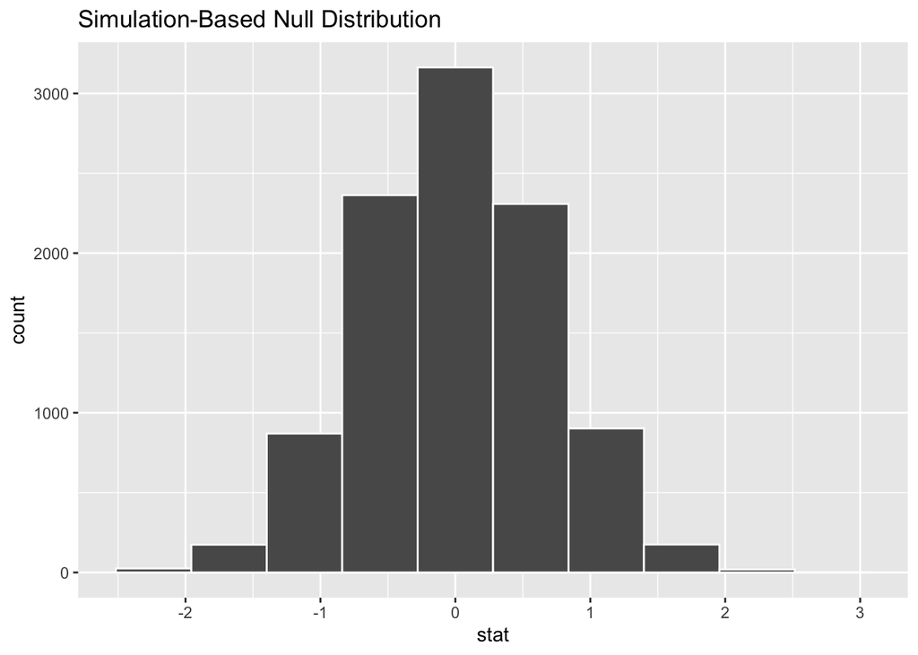

```r
visualize(null_distribution_covid, bins = 10)
```

```r
null_distribution_covid %>%
  get_p_value(obs_stat = obs_diff_means, direction = "both")
```

```
## # A tibble: 1 × 1
##   p_value
##     <dbl>
## 1       0
```

Our p-value was calculated as 0. While this isn’t literally true – we’re rounding here to get a value of 0 – it shows that it is incredibly unlikely that the relationship we’re seeing is just random chance. It’s technically possible, but we can be pretty sure of this relationship.

# Confidence Interval

In order to find a confidence interval, which represents the likely true value of this relationship, we’ll first take a bootstrap distribution. This is a series of sub-samples from our data that will each have its own difference in means.

```r
bootstrap_distribution <- covid_small %>%
  specify(formula = age ~ survived) %>%
  generate(reps = 10000, type = "bootstrap") %>%
  calculate(stat = "diff in means", order = c("yes", "no"))
glimpse(bootstrap_distribution)
```

```
## Rows: 10,000
## Columns: 2
## $ replicate <int> 1, 2, 3, 4, 5, 6, 7, 8, 9, 10, 11, 12, 13, 14, 15, 16, 17, 1…
## $ stat      <dbl> 19.32098, 19.86925, 19.08059, 20.61929, 20.28883, 18.68199, …
```

We can visualize this relationship, too.

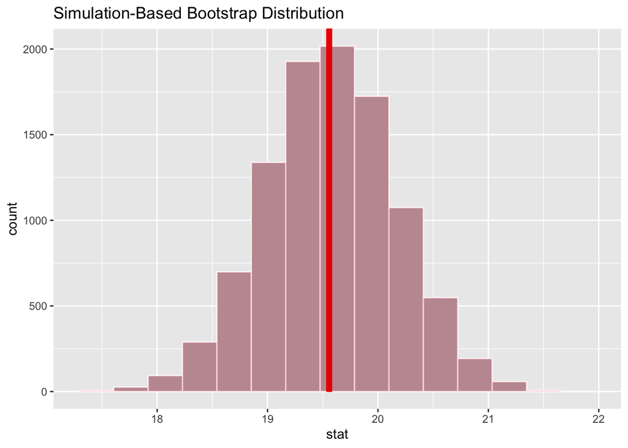

```r
visualise(bootstrap_distribution) +
  shade_p_value(obs_stat = obs_diff_means, direction = "both")
```

Let’s calculate our confidence interval using the 95% number we decided on above.

```r
percentile_ci <- bootstrap_distribution %>%
  get_confidence_interval(level = 0.95, type = "percentile")

percentile_ci
```

```
## # A tibble: 1 × 2
##   lower_ci upper_ci
##      <dbl>    <dbl>
## 1     18.4     20.7
```

And visualize it, as well..

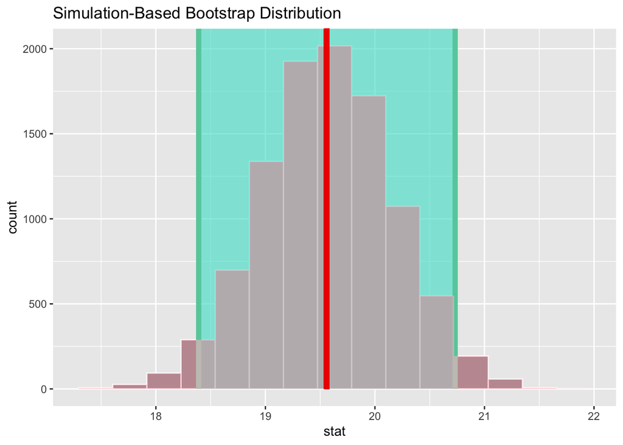

```r
visualize(bootstrap_distribution) +
  shade_confidence_interval(endpoints = percentile_ci)  +
  shade_p_value(obs_stat = obs_diff_means, direction = "both")
```

This graph shows our bootstrapped samples by the difference in means (difference in average age based on whether the patient died). Our observed difference is represented by the red line and the green shading shows our confidence interval.

# Conclusion

After all of this statistical work, what have we decided?

First, we found that there is a significant relationship between age and death in our original dataset. Patients who died in the hospital, according to this public dataset from the Mexican government, were older than patients who didn’t.

This work doesn’t quite mean that we can extrapolate this relationship to the rest of the world or say that there’s a direct causal relationship here. We have discovered a correlation that aligns with our hypothesis, but we also had to acknowledge along the way that this dataset has serious limitations. It didn’t track all deaths, was mediated by a random Kaggle user, and came from very early in the pandemic when governments the world over were struggling to respond and track impacts.

Thankfully, other scientists have done loads of research on this effect, so we do know that older people are at higher risk of death from Covid-19. Knowing this meant we could prioritize vaccines and make appropriate public health recommendations.